# Medium_articles

## Medium_Articles ------ Medium - Articles Similarity.

## Impoting Libraries

```python
import matplotlib.pyplot as plt
import seaborn as sns
import pandas as pd
import numpy as np
import string

from IPython.display import display # libraries to display dataframe and images
from PIL import Image

sns.set_theme(style="darkgrid")
pd.set_option("display.max_columns", 100)
%matplotlib inline
```

```python
# Setting up the NLTK to pre-processing textual data

import nltk
from nltk.corpus import stopwords, wordnet
from nltk.stem import PorterStemmer, LancasterStemmer, SnowballStemmer, WordNetLemmatizer
from nltk.tokenize import word_tokenize, sent_tokenize
nltk.download('punkt')
nltk.download('stopwords')
nltk.download('wordnet')
nltk.download('averaged_perceptron_tagger')
nltk.download('tagsets')
nltk.download('universal_tagset')
nltk.download('treebank')
```

```
True
```

```python
sns.set_theme(style="darkgrid")
pd.set_option("display.max_columns", 100)
%matplotlib inline
```

```python
! pip install spacy
```

```python
import spacy # Tokenization, Part-of-Speech (POS) tagging,Named Entity Recognition (NER),Dependency Parsing,Text Classification,Lemmatization)
from spacy import displacy
```

### Uploading the dataset

```python
articles = pd.read_csv("medium_articles_v3.csv")
display(articles.head(10))
print("Shape of dataframe : {}".format(articles.shape))
```

|  | link | title | sub_title | author | reading_time | text | id |
| --- | --- | --- | --- | --- | --- | --- | --- |
| 0 | https://towardsdatascience.com/ensemble-method... | Ensemble methods: bagging, boosting and stacking | Understanding the key concepts of ensemble lea... | Joseph Rocca | 20 | This post was co-written with Baptiste Rocca.\... | 1 |
| 1 | https://towardsdatascience.com/understanding-a... | Understanding AUC - ROC Curve | In Machine Learning, performance measurement i... | Sarang Narkhede | 5 | In Machine Learning, performance measurement i... | 2 |
| 2 | https://towardsdatascience.com/how-to-work-wit... | How to work with object detection datasets in ... | A comprehensive guide to defining, loading, ex... | Eric Hofesmann | 10 | Microsoft's Common Objects in Context dataset ... | 3 |
| 3 | https://towardsdatascience.com/11-dimensionali... | 11 Dimensionality reduction techniques you sho... | Reduce the size of your dataset while keeping ... | Rukshan Pramoditha | 16 | In both Statistics and Machine Learning, the n... | 4 |
| 4 | https://towardsdatascience.com/the-time-series... | The Time Series Transformer | Attention Is All You Need they said. Is it a m... | Theodoros Ntakouris | 6 | Attention Is All You Need they said. Is it a m... | 5 |
| 5 | https://netflixtechblog.com/learning-a-persona... | Learning a Personalized Homepage | how to best tailor each member's homepage to m... | Netflix Technology Blog | 15 | by Chris Alvino and Justin Basilico\nAs we've ... | 6 |
| 6 | https://towardsdatascience.com/6-data-science-... | 6 Data Science Certificates To Level Up Your C... | Pump up your portfolio and get closer to your ... | Sara A. Metwalli | 6 | Because of the appeal of the field of data sci... | 7 |
| 7 | https://towardsdatascience.com/transformers-ex... | Transformers Explained Visually (Part 2): How ... | A Gentle Guide to the Transformer under the ho... | Ketan Doshi | 11 | This is the second article in my series on Tra... | 8 |
| 8 | https://medium.com/coders-camp/60-python-proje... | 60 Python Projects with Source Code | 60 Python Projects with Source code solved and... | Aman Kharwal | 2 | Python has been in the top 10 popular programm... | 9 |
| 9 | https://towardsdatascience.com/geometric-found... | Geometric foundations of Deep Learning | Geometric Deep Learning is an attempt to unify... | Michael Bronstein | 13 | This blog post was co-authored with Joan Bruna... | 10 |

```
Shape of dataframe : (208, 7)
```

```python
from pprint import pprint

pprint(articles.iloc[1].to_dict(), compact=True)
```

```
{'author': 'Sarang Narkhede',
 'id': 2,
 'link': 'https://towardsdatascience.com/understanding-auc-roc-curve-68b2303cc9c5?source=tag_archive---------1-----------------------',
 'reading_time': 5,
 'sub_title': 'In Machine Learning, performance measurement is an essential '
              'task. So when it comes to a classification problem, we can '
              'count on an AUC - ROC Curve. When we need to check or visualize '
              'the performance...',
 'text': 'In Machine Learning, performance measurement is an essential task. '
         'So when it comes to a classification problem, we can count on an AUC '
         '- ROC Curve. When we need to check or visualize the performance of '
         'the multi-class classification problem, we use the AUC (Area Under '
         'The Curve) ROC (Receiver Operating Characteristics) curve. It is one '
         'of the most important evaluation metrics for checking any '
         "classification model's performance. It is also written as AUROC "
         '(Area Under the Receiver Operating Characteristics)\n'
         'Note: For better understanding, I suggest you read my article about '
         'Confusion Matrix.\n'
         'This blog aims to answer the following questions:\n'
         '1. What is the AUC - ROC Curve?\n'
         '2. Defining terms used in AUC and ROC Curve.\n'
         '3. How to speculate the performance of the model?\n'
         '4. Relation between Sensitivity, Specificity, FPR, and Threshold.\n'
         '5. How to use AUC - ROC curve for the multiclass model?\n'
         'AUC - ROC curve is a performance measurement for the classification '
         'problems at various threshold settings. ROC is a probability curve '
         'and AUC represents the degree or measure of separability. It tells '
         'how much the model is capable of distinguishing between classes. '
         'Higher the AUC, the better the model is at predicting 0 classes as 0 '
         'and 1 classes as 1. By analogy, the Higher the AUC, the better the '
         'model is at distinguishing between patients with the disease and no '
         'disease.\n'
         'The ROC curve is plotted with TPR against the FPR where TPR is on '
         'the y-axis and FPR is on the x-axis.\n'
         'An excellent model has AUC near to the 1 which means it has a good '
         'measure of separability. A poor model has an AUC near 0 which means '
         'it has the worst measure of separability. In fact, it means it is '
         'reciprocating the result. It is predicting 0s as 1s and 1s as 0s. '
         'And when AUC is 0.5, it means the model has no class separation '
         'capacity whatsoever.\n'
```

[output cut: 33 more lines]

```
         'example, If you have three classes named X, Y, and Z, you will have '
         'one ROC for X classified against Y and Z, another ROC for Y '
         'classified against X and Z, and the third one of Z classified '
         'against Y and X.\n'
         'Thanks for Reading.\n'
         "I hope I've given you some understanding of what exactly is the AUC "
         '- ROC Curve. If you like this post, a tad of extra motivation will '
         'be helpful by giving this post some claps . I am always open to your '
         'questions and suggestions. You can share this on Facebook, Twitter, '
         'Linkedin, so someone in need might stumble upon this.\n'
         'You can reach me at:\n'
         'LinkedIn: https://www.linkedin.com/in/narkhedesarang/\n'
         'Twitter: https://twitter.com/narkhede_sarang\n'
         'Github: https://github.com/TheSarang\n',
 'title': 'Understanding AUC - ROC Curve'}
```

## Statistical summary

```python
articles.describe(include='all')
```

|  | link | title | sub_title | author | reading_time | text | id |
| --- | --- | --- | --- | --- | --- | --- | --- |
| count | 208 | 208 | 208 | 208 | 208.000000 | 208 | 208.000000 |
| unique | 208 | 208 | 204 | 179 | NaN | 208 | NaN |
| top | https://towardsdatascience.com/ensemble-method... | Ensemble methods: bagging, boosting and stacking | Update: This article is part of a series. Chec... | Adam Geitgey | NaN | This post was co-written with Baptiste Rocca.\... | NaN |
| freq | 1 | 1 | 4 | 5 | NaN | 1 | NaN |
| mean | NaN | NaN | NaN | NaN | 12.375000 | NaN | 107.091346 |
| std | NaN | NaN | NaN | NaN | 13.880224 | NaN | 62.575453 |
| min | NaN | NaN | NaN | NaN | 2.000000 | NaN | 1.000000 |
| 25% | NaN | NaN | NaN | NaN | 6.000000 | NaN | 52.750000 |
| 50% | NaN | NaN | NaN | NaN | 9.000000 | NaN | 107.500000 |
| 75% | NaN | NaN | NaN | NaN | 13.000000 | NaN | 162.250000 |
| max | NaN | NaN | NaN | NaN | 149.000000 | NaN | 214.000000 |

### Ditsribution of reading times(only integer variable)

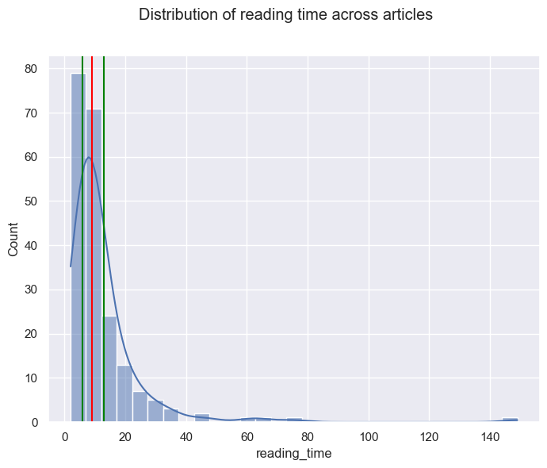

```python
# ditsribution of reading times in our corpus

fig, axes = plt.subplots(figsize = (8, 6))
sns.histplot(articles["reading_time"], kde=True, ax = axes)

# Computing percentile of the reading_time data.

first_q = np.percentile(articles["reading_time"], 25)
second_q = np.percentile(articles["reading_time"], 50)
third_q = np.percentile(articles["reading_time"], 75)
plt.axvline(first_q, color = "green")
plt.axvline(second_q, color = "red")
plt.axvline(third_q, color = "green")
plt.suptitle("Distribution of reading time across articles")
plt.show()
```

It is a right skewed distribution, indicating that the majority of articles are quick read, while a few are very long. The median reading time is 9 minutes

#### Relating the reading time with article length

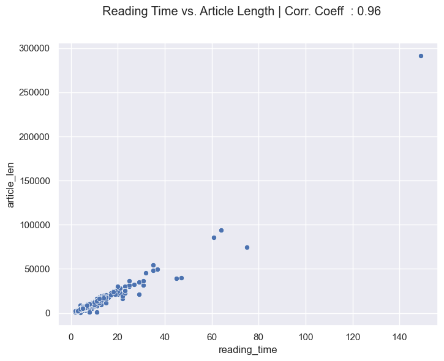

```python
from scipy.stats import pearsonr

articles["article_len"] = articles["text"].apply(lambda x : len(x))

# scatterplot
fig, axes = plt.subplots(figsize = (8, 6))
sns.scatterplot(x = articles["reading_time"], y = articles["article_len"])
# Pearson correlation coefficient to measure the linear relationship between two set of values.
corr_coeff, _ = pearsonr(articles["reading_time"], articles["article_len"])

plt.suptitle("Reading Time vs. Article Length | Corr. Coeff  : {}".format(round(corr_coeff, 2)))
plt.show()
```

The reading time and article length are highly correlated.

## similarity between articles on similar topics

```python
for author, count in dict(articles["author"].value_counts()).items():
    if(count < 2):
        continue
    print("Articles by {} :".format(author))
    for title in articles[articles["author"] == author]["title"].values:
        print(title)
    print("-"*120)
```

```
Articles by Adam Geitgey :
Machine Learning is Fun Part 5: Language Translation with Deep Learning and the Magic of Sequences
Machine Learning is Fun! Part 4: Modern Face Recognition with Deep Learning
Machine Learning is Fun! Part 3: Deep Learning and Convolutional Neural Networks
Machine Learning is Fun! Part 2
Machine Learning is Fun Part 6: How to do Speech Recognition with Deep Learning
------------------------------------------------------------------------------------------------------------------------
Articles by Joseph Rocca :
Ensemble methods: bagging, boosting and stacking
Understanding Variational Autoencoders (VAEs)
Understanding Generative Adversarial Networks (GANs)
------------------------------------------------------------------------------------------------------------------------
Articles by Natassha Selvaraj :
I tripled my income with data science. Here's how.
How to Land a Data Analytics Job in 6 Months
Top 10 Data Science Projects for Beginners
------------------------------------------------------------------------------------------------------------------------
Articles by Chris Zaire :
5 Online Courses I Took as a Self-Taught Data Scientist
Is Data Science Still a Rising Career in 2021
------------------------------------------------------------------------------------------------------------------------
Articles by Dario Radecic :
Are The New M1 Macbooks Any Good for Data Science? Let's Find Out
Top 3 Reasons Why I Sold My M1 Macbook Pro as a Data Scientist
------------------------------------------------------------------------------------------------------------------------
Articles by Adi Bronshtein :
Simple and Multiple Linear Regression in Python
Train/Test Split and Cross Validation in Python
------------------------------------------------------------------------------------------------------------------------
Articles by Serge Faguet :
How to biohack your intelligence  with everything from sex to modafinil to MDMA
I'm 32 and spent $200k on biohacking. Became calmer, thinner, extroverted, healthier & happier.
------------------------------------------------------------------------------------------------------------------------
Articles by Will Koehrsen :
Hyperparameter Tuning the Random Forest in Python
Random Forest in Python
------------------------------------------------------------------------------------------------------------------------
Articles by Madison Hunter :
15 Habits I Learned from Highly Effective Data Scientists
How to Study for the Google Data Analytics Professional Certificate
```

[output cut: 46 more lines]

```
Transformers Explained Visually (Part 2): How it works, step-by-step
Transformers Explained Visually (Part 3): Multi-head Attention, deep dive
------------------------------------------------------------------------------------------------------------------------
Articles by Aman Kharwal :
60 Python Projects with Source Code
180 Data Science and Machine Learning Projects with Python
------------------------------------------------------------------------------------------------------------------------
Articles by Mahmoud Harmouch :
17 Clustering Algorithms Used In Data Science and Mining
17 types of similarity and dissimilarity measures used in data science.
------------------------------------------------------------------------------------------------------------------------
Articles by Sara A. Metwalli :
6 Data Science Certificates To Level Up Your Career
6 Machine Learning Certificates to Pursue in 2021
------------------------------------------------------------------------------------------------------------------------
```

From the above output, we can make out that not only the authors tend to write multiple articles on the same topic, but also, there are multiple authors writing on the same topic.

### Preprocessing

```python
!pip install contractions -q
```

```python
import contractions
import re
```

```python
def process_sentence(sentence, nlp_object):
    # Convert to lowercase
    sentence = sentence.lower()

    # Exapnding contractions
    sentence = contractions.fix(sentence)

    # Lemmatization and removing stopwords
    doc = nlp_object(sentence)
    sentence = " ".join([token.lemma_ for token in doc if not token.is_stop])

    # Remove punctuation
    for p in string.punctuation:
        sentence = sentence.replace(p, " ")
    sentence = re.sub(r"\s+", " ", sentence) # Replace all whitespace characters with space

    return sentence
```

```python
# tqdm to see real time progress

from tqdm.notebook import tqdm
tqdm.pandas()

nlp = spacy.load('en_core_web_sm') # English pipeline optimized for CPU

def process_article(article_text, nlp_object):
    processed_article_sentences = []
    # using nltk sentence tokenizer
    for sentence in sent_tokenize(article_text):
        # preprocessing each sentence using our process_sentence function
        processed_article_sentences.append(process_sentence(sentence, nlp_object))
    # joining preprocessed sentence as a complete paragrams of the article
    return " ".join(processed_article_sentences)

articles["processed_text"] = articles["text"].progress_apply(lambda x : process_article(x, nlp))
```

Preprocessing and tokenization of the article text done.

## Similarity between documents

#### Similarity using BOW (Bag of Words)

```python
# BOW representation of the dataset Using CountVectorizer from scikit-learn

from sklearn.feature_extraction.text import CountVectorizer
count_vectorizer = CountVectorizer(min_df=5)

# min_df: ignore terms that have a document frequency strictly lower than the given threshold.

# Learn the vocabulary dictionary and return document-term matrix
bow_features = count_vectorizer.fit_transform(articles["processed_text"]).todense() # todense() returns a matrix

# create dataframe
bow_features_df = pd.DataFrame(bow_features)
bow_features_df.columns = count_vectorizer.get_feature_names_out() # Get output feature names for dataframe columns.
bow_features_df["TITLE"] = articles["title"]
bow_features_df["ID"] = articles["id"]
display(bow_features_df)
```

|  | 00 | 000 | 01 | 05 | 06 | 07 | 10 | 100 | 1000 | 101 | 10k | 10x | 11 | 12 | 120 | 125 | 128 | 13 | 14 | 15 | 150 | 16 | 17 | 18 | 19 | 1980 | 1989 | 1990 | 1k | … |
| --- | --- | --- | --- | --- | --- | --- | --- | --- | --- | --- | --- | --- | --- | --- | --- | --- | --- | --- | --- | --- | --- | --- | --- | --- | --- | --- | --- | --- | --- | --- |
| 0 | 0 | 0 | 0 | 0 | 0 | 0 | 0 | 0 | 0 | 0 | 0 | 0 | 0 | 0 | 0 | 0 | 0 | 0 | 0 | 0 | 0 | 0 | 0 | 0 | 0 | 0 | 0 | 0 | 0 | … |
| 1 | 0 | 0 | 0 | 0 | 0 | 0 | 0 | 0 | 0 | 0 | 0 | 0 | 0 | 0 | 0 | 0 | 0 | 0 | 0 | 0 | 0 | 0 | 0 | 0 | 0 | 0 | 0 | 0 | 0 | … |
| 2 | 0 | 0 | 0 | 0 | 1 | 0 | 1 | 0 | 0 | 0 | 0 | 0 | 0 | 0 | 0 | 0 | 0 | 0 | 0 | 0 | 0 | 0 | 0 | 0 | 0 | 0 | 0 | 0 | 0 | … |
| 3 | 0 | 0 | 0 | 0 | 0 | 0 | 0 | 0 | 0 | 0 | 0 | 0 | 1 | 0 | 0 | 0 | 0 | 0 | 1 | 1 | 0 | 0 | 0 | 0 | 0 | 0 | 0 | 0 | 0 | … |
| 4 | 0 | 0 | 0 | 0 | 0 | 0 | 0 | 0 | 0 | 0 | 0 | 0 | 0 | 0 | 0 | 0 | 0 | 0 | 0 | 0 | 0 | 0 | 0 | 0 | 0 | 0 | 0 | 0 | 0 | … |
| ... | ... | ... | ... | ... | ... | ... | ... | ... | ... | ... | ... | ... | ... | ... | ... | ... | ... | ... | ... | ... | ... | ... | ... | ... | ... | ... | ... | ... | ... | … |
| 203 | 1 | 0 | 0 | 0 | 0 | 0 | 1 | 0 | 0 | 0 | 0 | 0 | 0 | 1 | 0 | 0 | 0 | 0 | 0 | 0 | 0 | 0 | 0 | 0 | 0 | 0 | 0 | 0 | 0 | … |
| 204 | 0 | 0 | 0 | 0 | 0 | 0 | 0 | 0 | 0 | 0 | 0 | 0 | 0 | 1 | 0 | 0 | 0 | 0 | 1 | 0 | 0 | 0 | 0 | 0 | 0 | 0 | 0 | 0 | 0 | … |
| 205 | 0 | 0 | 0 | 0 | 0 | 0 | 1 | 0 | 0 | 0 | 0 | 0 | 1 | 1 | 0 | 0 | 0 | 0 | 0 | 0 | 0 | 0 | 0 | 0 | 0 | 0 | 0 | 0 | 0 | … |
| 206 | 0 | 0 | 0 | 0 | 0 | 0 | 5 | 0 | 0 | 0 | 0 | 0 | 0 | 0 | 0 | 0 | 0 | 0 | 0 | 3 | 0 | 0 | 0 | 2 | 0 | 0 | 0 | 0 | 0 | … |
| 207 | 0 | 0 | 0 | 0 | 0 | 0 | 1 | 0 | 0 | 0 | 0 | 0 | 0 | 0 | 0 | 0 | 0 | 0 | 0 | 0 | 0 | 0 | 0 | 0 | 0 | 0 | 0 | 0 | 0 | … |

208 rows × 3715 columns

## Visualize this high dimensional data

```python
from sklearn.manifold import TSNE

# using t-sne to observe any trends, and clusters.
tsne = TSNE(n_components=2) # n_components: estimated number of components
tsne_bow_features = tsne.fit_transform(bow_features_df[count_vectorizer.get_feature_names_out()].values)
tsne_bow_features_df = pd.DataFrame(tsne_bow_features)
tsne_bow_features_df.columns = ["C1", "C2"]
tsne_bow_features_df["TITLE"] = bow_features_df["TITLE"]
tsne_bow_features_df["ID"] = bow_features_df["ID"]

display(tsne_bow_features_df)
```

|  | C1 | C2 | TITLE | ID |
| --- | --- | --- | --- | --- |
| 0 | 4.678334 | 0.676908 | Ensemble methods: bagging, boosting and stacking | 1 |
| 1 | -0.525218 | -0.337440 | Understanding AUC - ROC Curve | 2 |
| 2 | 3.179588 | 0.410891 | How to work with object detection datasets in ... | 3 |
| 3 | 4.088364 | -0.551824 | 11 Dimensionality reduction techniques you sho... | 4 |
| 4 | 1.404219 | -1.041643 | The Time Series Transformer | 5 |
| ... | ... | ... | ... | ... |
| 203 | -5.789235 | -2.580537 | Type 2 Diabetes Reversal The Quick Start Guide | 210 |
| 204 | -5.116230 | -1.458020 | How a 22 Day Water Fast Changed My Life | 211 |
| 205 | -4.967505 | -1.612653 | Breaking Your Fast | 212 |
| 206 | -4.958772 | 0.348647 | 11 Unusual Tips for How to Wake Up Early | 213 |
| 207 | -6.518097 | -1.696942 | The 3 Biggest Mistakes Women Make On The Ketog... | 214 |

208 rows × 4 columns

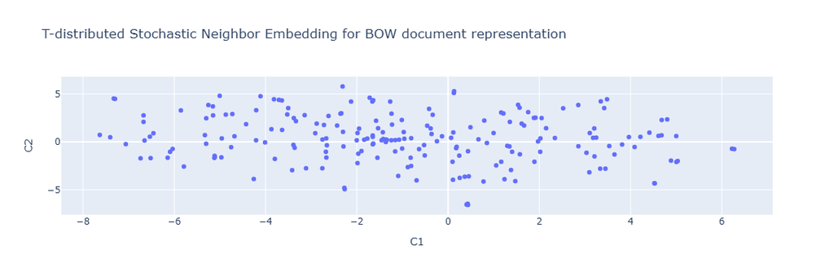

```python
# scatter plot of t-sne for the BOW representation
import plotly.express as px

title = "T-distributed Stochastic Neighbor Embedding for BOW document representation"

fig = px.scatter(tsne_bow_features_df, x="C1", y="C2", hover_data=['TITLE'], title=title)
fig.show()
```

From the above graph,We see most of documents to the one half describe articles related to Deep learning. Articles plotted to the other half describe Coronavirus, Economics and other miscellaneous articles.

### Similarity between documents using BOW representation.

```python
from sklearn.metrics.pairwise import cosine_similarity

def get_similar_documents(all_article_rep_df, article_id, features):
    # extracting features of a article
    this_article_rep = all_article_rep_df[all_article_rep_df["ID"] == article_id][features]
    other_article_rep = all_article_rep_df[all_article_rep_df["ID"] != article_id][features]
    # calculating cosine similarity
    similarity_matrix = cosine_similarity(this_article_rep, other_article_rep)
    similar_articles = list(zip(similarity_matrix[0].tolist(), all_article_rep_df["TITLE"].tolist()))
    # sorting
    similar_articles = sorted(similar_articles, key = lambda x : x[0], reverse = True)
    print("Reference Article : {}".format(all_article_rep_df[all_article_rep_df["ID"] == article_id]["TITLE"].values[0]))

    print("**** Similar Articles ****")
    # top 5 similar articles
    for score, title in similar_articles[:5]:
        print(title)
    print()

# Let us check top 5 similar articles for some of the articles in our corpus
get_similar_documents(bow_features_df, 90, count_vectorizer.get_feature_names_out())
get_similar_documents(bow_features_df, 80, count_vectorizer.get_feature_names_out())
get_similar_documents(bow_features_df, 150, count_vectorizer.get_feature_names_out())
get_similar_documents(bow_features_df, 205, count_vectorizer.get_feature_names_out())
```

```
Reference Article : 17 types of similarity and dissimilarity measures used in data science.
**** Similar Articles ****
9 Distance Measures in Data Science
17 Clustering Algorithms Used In Data Science and Mining
Machine Learning Basics with the K-Nearest Neighbors Algorithm
OVER 100 Data Scientist Interview Questions and Answers!
Fundamental Techniques of Feature Engineering for Machine Learning

Reference Article : TensorFlow Tutorial Part 1
**** Similar Articles ****
How to go from a Python newbie to a Google Certified TensorFlow Developer under two months
Enchanted Random Forest
The 7 Best Data Science and Machine Learning Podcasts
PCA using Python (scikit-learn)
Time Series Forecasting with PyCaret Regression Module

Reference Article : The One Word That Explains Why Economics Professors Are Not Billionaires
**** Similar Articles ****
Why People Still Don't Get Cryptocurrency
You May Have A Poor Person's Mindset And Not Know It
You Will Never Be Rich If You Keep Doing These 10 things
How I transformed $6,000 to $3,000,000
The Exact Steps I Followed to Make $1,500+ of Passive Income Every Month

Reference Article : How I lost 10kg in 60 days: My 7-step weight loss plan
**** Similar Articles ****
10 Things You Can Do This Morning To Heal Your Anxiety
How to lose 10+ pounds of fat a month- even if you have a slow metabolism
The Diet & Workout Plan of a Full-Time Traveling Family  HIS
The cure for type 2 diabetes is known, but few are aware
The Easiest Way to Lose 125 Pounds Is to Gain 175 Pounds
```

The suggested articles do seem to be similar to those in reference. BOW looks for presence and absence of words in different documents, so documents which have similar words would also have similar BOW representation, and hence would be more similar.

### Similarity using TF-IDF

```python
# TF-IDF representation of the dataset Using TfidfVectorizer from scikit-learn
from sklearn.feature_extraction.text import TfidfVectorizer
tfidf_vectorizer = TfidfVectorizer(min_df=5)
# min_df: ignore terms that have a document frequency strictly lower than the given threshold.

# todense() returns a matrix
tfidf_features = tfidf_vectorizer.fit_transform(articles["processed_text"]).todense()  # todense() returns a matrix

# create dataframe
tfidf_features_df = pd.DataFrame(tfidf_features)
tfidf_features_df.columns = tfidf_vectorizer.get_feature_names_out()  # Get output feature names for dataframe columns.
tfidf_features_df["TITLE"] = articles["title"]
tfidf_features_df["ID"] = articles["id"]
display(tfidf_features_df)
```

|  | 00 | 000 | 01 | 05 | 06 | 07 | 10 | 100 | 1000 | 101 | 10k | 10x | 11 | 12 | 120 | 125 | 128 | 13 | 14 | 15 | 150 | 16 | 17 | 18 | 19 | 1980 | 1989 | 1990 | 1k | … |
| --- | --- | --- | --- | --- | --- | --- | --- | --- | --- | --- | --- | --- | --- | --- | --- | --- | --- | --- | --- | --- | --- | --- | --- | --- | --- | --- | --- | --- | --- | --- |
| 0 | 0.000000 | 0.0 | 0.0 | 0.0 | 0.000000 | 0.0 | 0.000000 | 0.0 | 0.0 | 0.0 | 0.0 | 0.0 | 0.000000 | 0.000000 | 0.0 | 0.0 | 0.0 | 0.0 | 0.000000 | 0.000000 | 0.0 | 0.0 | 0.0 | 0.000000 | 0.0 | 0.0 | 0.0 | 0.0 | 0.0 | … |
| 1 | 0.000000 | 0.0 | 0.0 | 0.0 | 0.000000 | 0.0 | 0.000000 | 0.0 | 0.0 | 0.0 | 0.0 | 0.0 | 0.000000 | 0.000000 | 0.0 | 0.0 | 0.0 | 0.0 | 0.000000 | 0.000000 | 0.0 | 0.0 | 0.0 | 0.000000 | 0.0 | 0.0 | 0.0 | 0.0 | 0.0 | … |
| 2 | 0.000000 | 0.0 | 0.0 | 0.0 | 0.019284 | 0.0 | 0.008320 | 0.0 | 0.0 | 0.0 | 0.0 | 0.0 | 0.000000 | 0.000000 | 0.0 | 0.0 | 0.0 | 0.0 | 0.000000 | 0.000000 | 0.0 | 0.0 | 0.0 | 0.000000 | 0.0 | 0.0 | 0.0 | 0.0 | 0.0 | … |
| 3 | 0.000000 | 0.0 | 0.0 | 0.0 | 0.000000 | 0.0 | 0.000000 | 0.0 | 0.0 | 0.0 | 0.0 | 0.0 | 0.006737 | 0.000000 | 0.0 | 0.0 | 0.0 | 0.0 | 0.008669 | 0.006796 | 0.0 | 0.0 | 0.0 | 0.000000 | 0.0 | 0.0 | 0.0 | 0.0 | 0.0 | … |
| 4 | 0.000000 | 0.0 | 0.0 | 0.0 | 0.000000 | 0.0 | 0.000000 | 0.0 | 0.0 | 0.0 | 0.0 | 0.0 | 0.000000 | 0.000000 | 0.0 | 0.0 | 0.0 | 0.0 | 0.000000 | 0.000000 | 0.0 | 0.0 | 0.0 | 0.000000 | 0.0 | 0.0 | 0.0 | 0.0 | 0.0 | … |
| ... | ... | ... | ... | ... | ... | ... | ... | ... | ... | ... | ... | ... | ... | ... | ... | ... | ... | ... | ... | ... | ... | ... | ... | ... | ... | ... | ... | ... | ... | … |
| 203 | 0.015154 | 0.0 | 0.0 | 0.0 | 0.000000 | 0.0 | 0.006358 | 0.0 | 0.0 | 0.0 | 0.0 | 0.0 | 0.000000 | 0.008112 | 0.0 | 0.0 | 0.0 | 0.0 | 0.000000 | 0.000000 | 0.0 | 0.0 | 0.0 | 0.000000 | 0.0 | 0.0 | 0.0 | 0.0 | 0.0 | … |
| 204 | 0.000000 | 0.0 | 0.0 | 0.0 | 0.000000 | 0.0 | 0.000000 | 0.0 | 0.0 | 0.0 | 0.0 | 0.0 | 0.000000 | 0.019866 | 0.0 | 0.0 | 0.0 | 0.0 | 0.027918 | 0.000000 | 0.0 | 0.0 | 0.0 | 0.000000 | 0.0 | 0.0 | 0.0 | 0.0 | 0.0 | … |
| 205 | 0.000000 | 0.0 | 0.0 | 0.0 | 0.000000 | 0.0 | 0.016279 | 0.0 | 0.0 | 0.0 | 0.0 | 0.0 | 0.022684 | 0.020770 | 0.0 | 0.0 | 0.0 | 0.0 | 0.000000 | 0.000000 | 0.0 | 0.0 | 0.0 | 0.000000 | 0.0 | 0.0 | 0.0 | 0.0 | 0.0 | … |
| 206 | 0.000000 | 0.0 | 0.0 | 0.0 | 0.000000 | 0.0 | 0.043608 | 0.0 | 0.0 | 0.0 | 0.0 | 0.0 | 0.000000 | 0.000000 | 0.0 | 0.0 | 0.0 | 0.0 | 0.000000 | 0.036775 | 0.0 | 0.0 | 0.0 | 0.031277 | 0.0 | 0.0 | 0.0 | 0.0 | 0.0 | … |
| 207 | 0.000000 | 0.0 | 0.0 | 0.0 | 0.000000 | 0.0 | 0.007903 | 0.0 | 0.0 | 0.0 | 0.0 | 0.0 | 0.000000 | 0.000000 | 0.0 | 0.0 | 0.0 | 0.0 | 0.000000 | 0.000000 | 0.0 | 0.0 | 0.0 | 0.000000 | 0.0 | 0.0 | 0.0 | 0.0 | 0.0 | … |

208 rows × 3715 columns

```python
tsne = TSNE(n_components=2)
tsne_tfidf_features = tsne.fit_transform(tfidf_features_df[tfidf_vectorizer.get_feature_names_out()].values)
tsne_tfidf_features_df = pd.DataFrame(tsne_tfidf_features)
tsne_tfidf_features_df.columns = ["C1", "C2"]
tsne_tfidf_features_df["TITLE"] = tfidf_features_df["TITLE"]
display(tsne_tfidf_features_df)
```

|  | C1 | C2 | TITLE |
| --- | --- | --- | --- |
| 0 | 9.762344 | 11.015292 | Ensemble methods: bagging, boosting and stacking |
| 1 | 14.255919 | 13.017860 | Understanding AUC - ROC Curve |
| 2 | 6.873959 | 6.165265 | How to work with object detection datasets in ... |
| 3 | 12.444081 | 8.057103 | 11 Dimensionality reduction techniques you sho... |
| 4 | 3.163160 | 13.177513 | The Time Series Transformer |
| ... | ... | ... | ... |
| 203 | -19.331902 | -5.387913 | Type 2 Diabetes Reversal The Quick Start Guide |
| 204 | -15.034296 | -4.478994 | How a 22 Day Water Fast Changed My Life |
| 205 | -15.781659 | -3.918873 | Breaking Your Fast |
| 206 | -12.157654 | -9.466602 | 11 Unusual Tips for How to Wake Up Early |
| 207 | -17.537691 | -3.023856 | The 3 Biggest Mistakes Women Make On The Ketog... |

208 rows × 3 columns

### Viualization for similarity using TF-IDF

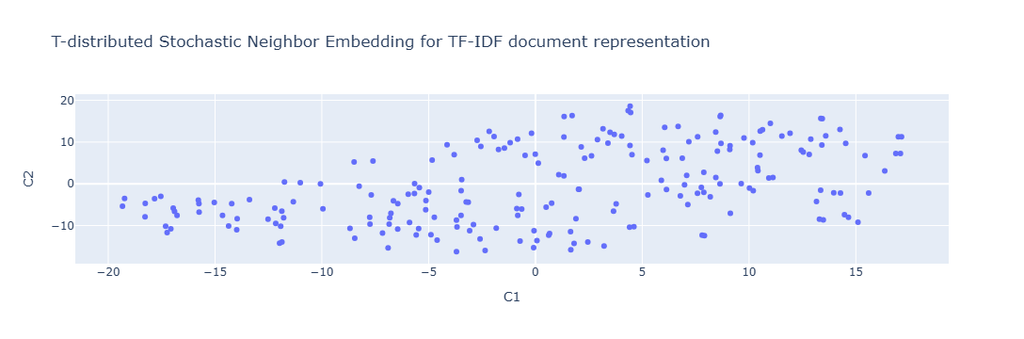

```python
title = "T-distributed Stochastic Neighbor Embedding for TF-IDF document representation"
fig = px.scatter(tsne_tfidf_features_df, x="C1", y="C2", hover_data=['TITLE'], title=title)
fig.show()
```

From the above scatter plot, we see points usually allong three different directions. while hovering over the points,we see the three directions contains articles broadly on the following topics - Data Science/Machine Learning Health Finance

```python
# Let us check top 5 similar articles for some of the articles in our corpus

get_similar_documents(tfidf_features_df, 90, tfidf_vectorizer.get_feature_names_out())
get_similar_documents(tfidf_features_df, 80, tfidf_vectorizer.get_feature_names_out())
get_similar_documents(tfidf_features_df, 150, tfidf_vectorizer.get_feature_names_out())
get_similar_documents(tfidf_features_df, 205, tfidf_vectorizer.get_feature_names_out())
```

```
Reference Article : 17 types of similarity and dissimilarity measures used in data science.
**** Similar Articles ****
9 Distance Measures in Data Science
17 Clustering Algorithms Used In Data Science and Mining
Machine Learning Basics with the K-Nearest Neighbors Algorithm
OVER 100 Data Scientist Interview Questions and Answers!
Fundamental Techniques of Feature Engineering for Machine Learning

Reference Article : TensorFlow Tutorial Part 1
**** Similar Articles ****
How to go from a Python newbie to a Google Certified TensorFlow Developer under two months
Enchanted Random Forest
Building RNN, LSTM, and GRU for time series using PyTorch
PCA using Python (scikit-learn)
Yes you should understand backprop

Reference Article : The One Word That Explains Why Economics Professors Are Not Billionaires
**** Similar Articles ****
You Will Never Be Rich If You Keep Doing These 10 things
Why People Still Don't Get Cryptocurrency
You May Have A Poor Person's Mindset And Not Know It
How I transformed $6,000 to $3,000,000
4 Reasons Why Economists Make Great Data Scientists (And Why No One Tells Them)

Reference Article : How I lost 10kg in 60 days: My 7-step weight loss plan
**** Similar Articles ****
How to lose 10+ pounds of fat a month- even if you have a slow metabolism
10 Things You Can Do This Morning To Heal Your Anxiety
The Diet & Workout Plan of a Full-Time Traveling Family  HIS
The Science Behind Fat Metabolism
The cure for type 2 diabetes is known, but few are aware
```

TFIDF also seems to work well.

Conclusion: Medium articles in our corpus mainly belonged to Data Science, Health and Finance. In other words there are three (or maybe more) broad topics (Data Science/Machine Learning,Health and Finance), that our corpus talks about - this can be seggregated or identified using Topic Modeling. The vectorization techniques that we talked about are used extensively in text classification problems as well.